# Multiple Testing

Linda Angulo Lopez

04/01/2021

## Ask the right questions:

*“Which of the variables matter among the thousands should be measured?”*

*“How do we relate unrelated information?”*

*“How do we correct for errors?”*

```r
#R4.0 Environmental Set for:
library(knitr) # creating a pdf document ;
library(ggplot2) # making plots
library(reshape2) # data frames
```

[mySWIRL notes: Statistical_Inference](https://cran.r-project.org/web/packages/swirl/swirl.pdf)

# Multiple Testing

To avoid this many false positive we can use multiple test corrections, like the Bonferroni correction, by reducing $\alpha$ dramatically, however here too many results fail, so the False Discovery Rate, $FDR$ is simply limited in most disciplines with the Benjamini-Hochberg method, $BH$ this is much like the $k$ evaluation.

Both these methods adjust the threshold $\alpha$, an equivalent corrective approach is to adjust the $p$-values, then call all $p'_i$ < $\alpha$ significant.

## Status Quo vs Discoveries

- $m_0$ are actually true and
- $m$ - $m_0$ are actually false
- $R$ have been declared significant, these are discoveries
- A False Positive falsely claims a significant positive result, it is a Type I error, denoted $V$.
- A False Negative falsely claims a non-significant negative result, it is a Type II error, denoted $T$.
- So, the False Discovery Rate, $FDR$ is the expected value of the Type I errors over the discoveries: $E(V/R)$
- and the False Positive Rate, $FPR$, will be the expected value of the Type I errors over the true events: $E(V/m_0)$

*$FDR$ = $E(V/R)$*

*$FPR$ = $E(V/m_0)$*

### The Family Wise Error Rate, $FWER$

The probability of at least one false positive, $Pr$, that is $V$ >= 1, is the Family Wise Error Rate, $FWER$.

### Bonferroni correction

Is a correction test which dramatically reduces $\alpha$ to avoid many false positives, in big data analysis. We set $\alpha_F$ = $\alpha/m$ and call a test result significant if its $p$-value < $\alpha_F$. The drawback is that too many results would fail if this correction is applied.

Here you could adjust these by setting $p'_i$ = max($m$ * $p_i$, 1) for each $p$-value, then if you would call all $p'_i$ < $\alpha$ significant you will control the $FWER$.

## Limit the $FDR$

In the Benjamini-Hochberg method, $BH$ a $p$-values is compared to a value that depends on its ranking, $p_i$ <= ($\alpha$*$i$)/$m$.

This is equivalent to finding the largest $k$ such that $p_k$ <= ($k$ * $\alpha$)/$m$, for a given alpha and then rejecting all the null hypotheses for $i$ = 1,…,$k$.

The following chart shows the $p$-values for 10 tests performed at the $\alpha$=.2 level and three cutoff lines. The $p$-values are shown in order from left to right along the x-axis.

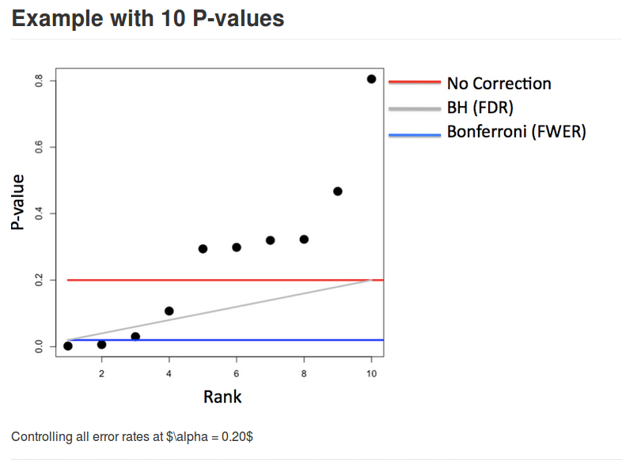

JHU chart

- The red line is the threshold for No Corrections (p-values are compared to alpha=.2),
- the blue line is the Bonferroni threshold, alpha=.2/10 = .02, and
- the gray line shows the Benjamini-Hochberg correction.

## Worked Examples:

- no relation

```r
## create an array of p-values

set.seed(1010093)
pValues <- rep(NA,1000)
for(i in 1:1000){
  y <- rnorm(20)
  x <- rnorm(20)
  pValues[i] <- summary(lm(y ~ x))$coeff[2,4]
}
#inspect array
head(pValues)
```

```
## [1] 0.5334915 0.2765785 0.8380943 0.6721730 0.8122037 0.4078675
```

```r
#count p < .05
sum(pValues < 0.05)
```

```
## [1] 51
```

### There should be close to 50 false positives, we can control this with the R function p.adjust()

```r
sum(p.adjust(pValues,method="bonferroni") < 0.05)
```

```
## [1] 0
```

- The above method should be more radical than the next

```r
sum(p.adjust(pValues,method="BH") < 0.05)
```

```
## [1] 0
```

*but as there was no relation to begin will all false positive were eliminated.*

- Half of the is paired

```r
## create an array of p-values

set.seed(1010093)
pValues2 <- rep(NA,1000)
for(i in 1:1000){
  x <- rnorm(20)
  # First 500 beta=0, last 500 beta=2
  if(i <= 500){y <- rnorm(20)}else{ y <- rnorm(20,mean=2*x)}
  pValues2[i] <- summary(lm(y ~ x))$coeff[2,4]
}
trueStatus <- rep(c("zero","not zero"),each=500)

#inspect array
tail(trueStatus)
```

```
## [1] "not zero" "not zero" "not zero" "not zero" "not zero" "not zero"
```

### We can count & tabulate the each combination (TRUE,“zero”), (TRUE,“not zero”), (FALSE,“zero”), and (FALSE,“not zero”)

```r
table(pValues2 < 0.05, trueStatus)
```

```
##        trueStatus
##         not zero zero
##   FALSE        0  476
##   TRUE       500   24
```

This is the result without any correction, there should be about 5% false positives, this should be reduced if we apply a correction.

```r
table(p.adjust(pValues2,method="bonferroni") < 0.05, trueStatus)
```

```
##        trueStatus
##         not zero zero
##   FALSE       23  500
##   TRUE       477    0
```

And here is a much less stringent control.

```r
table(p.adjust(pValues2,method="BH") < 0.05, trueStatus)
```

```
##        trueStatus
##         not zero zero
##   FALSE        0  487
##   TRUE       500   13
```

Here is a plot from the SWIRL repo

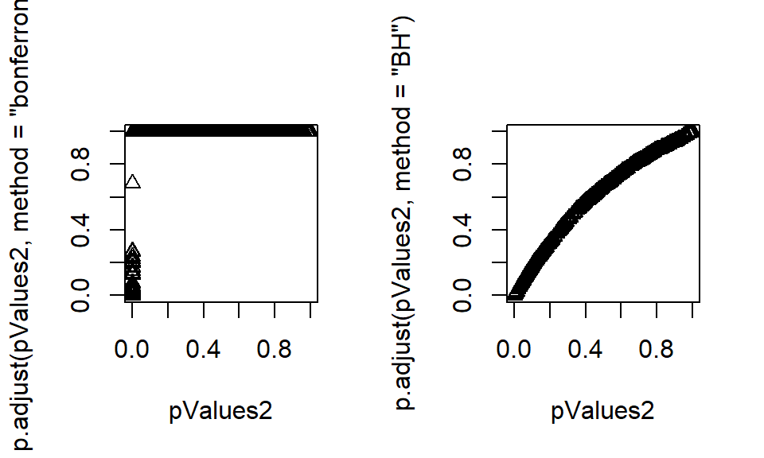

```r
plot.new()
par(mfrow=c(1,2))
plot(pValues2,p.adjust(pValues2,method="bonferroni"),pch=2)
plot(pValues2,p.adjust(pValues2,method="BH"),pch=2)
```

We see that with the Bonferroni control only a few of the adjusted values are below 1. For the BH, the adjusted values are slightly larger than the original values.

### Documenting file creation

It’s useful to record some information about how your file was created.

- File creation date: 2021-01-04
- R version 4.0.2 (2020-06-22)
- R version (short form): 4.0.2
- `mosaic` package version: 1.8.2

`RECAP: hypothesis testing`

- A Type I error is rejecting a true hypothesis or “convicting an innocent person”
- A Type II error is failing to reject a false hypothesis or “acquitting a guilty person”
- The null hypothesis, $H_0$, represents the status_quo and is assumed to be true.
- The test statistic is $\mu_a$, usually the mean of the alternative.
- The $\alpha$ levels are set before the test is conducted, often at 5%.
- The $p$ value is the probability under the null hypothesis of obtaining evidence as or more extreme than the test statistic.
- if a p-value is found to be less than alpha (say 0.05), then the test result is considered statistically significant, i.e., surprising and unusual, and the the status quo is rejected.

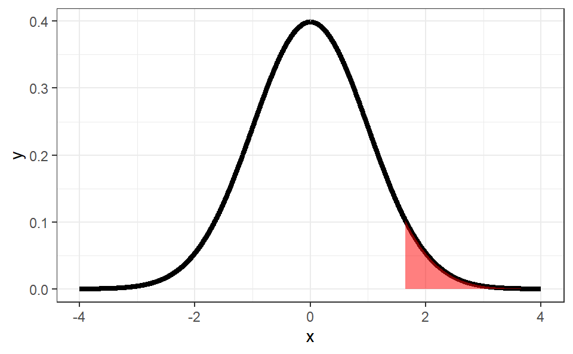

### Destination formats

- File can be knit to `HTML, PDF, or Word`.

### Documenting file creation

- File creation date: 2021-01-04
- R version 4.0.2 (2020-06-22)
- R version (short form): 4.0.2
- `mosaic` package version: 1.8.2
- Additional session information